# Actividad 5

Grupo 5

2026-04-29

## Contexto

En una emocionante competencia de cubos Rubik, participantes de Chile, Argentina, Colombia, Uruguay, Perú y Ecuador demostraron su destreza en resolver tres tipos de cubos: 2x2x2, 3x3x3 y Megaminx.

Después del Campeonato Mundial del Cubo, un grupo de investigación interesado en los tiempos que hicieron las jugadoras y los jugadores en la competencia, decidieron estudiar si el país y el tipo de cubo usado en cada prueba tienen influencia en los segundos que se tardan en resolverlos. Para ello usaron una muestra aleatoria de los datos de la competencia, en la cual participaron más de 10.000 personas, con las siguientes variables:

| Variable | Descripción |
| --- | --- |
| id | Identificador único de cada participante |
| pais | País que representa cada participante |
| tipo | Tipo de cubo usado en la prueba (2x2x2, 3x3x3, Megaminx) |
| tiempo | Tiempo, en segundos, que toma al participante en resolver el cubo de la prueba |

## Preguntas

1. ¿Existen diferencias en el tiempo de resolución de cubos 3x3x3 entre participantes de Chile, Colombia y Uruguay?

A partir de la pregunta podemos formular la hipótesis nula y alternativa a docimar:

$H_0$: El tiempo promedio de resolución de cubos 3x3x3 entre participantes de Chile, Colombia y Uruguay son iguales. Matemáticamente hablando: $\mu_{Chile} = \mu_{Colombia} = \mu_{Uruguay}$

$H_A$: El tiempo promedio de resolución de cubos 3x3x3 entre participantes de Chile, Colombia y Uruguay es dintinto para al menos 1 de los países. Matemáticamente hablando: $\exists$ $\mu_i \land \mu_j$ $|$ $\mu_i \neq \mu_j$

```r
# Se leen los datos
datos = read.csv2("EP05 Datos.csv", stringsAsFactors = TRUE, header = TRUE, sep = ";")

# Filtro de acuerdo a los paises de interes y el tipo requerido, quitando las columnas que no aportan informacion relevante
datos_chile <- datos %>% filter(pais == "Chile")
datos_chile <- datos_chile %>% filter(tipo == "3x3x3")
datos_chile <- datos_chile[, -c(1,2,3,4)]

datos_colombia<- datos %>% filter(pais == "Colombia")
datos_colombia <- datos_colombia %>% filter(tipo == "3x3x3")
datos_colombia <- datos_colombia[, -c(1,2,3,4)]

datos_uruguay<- datos %>% filter(pais == "Uruguay")
datos_uruguay <- datos_uruguay %>% filter(tipo == "3x3x3")
datos_uruguay <- datos_uruguay[, -c(1,2,3,4)]

datos_todos <- data.frame(tiempo = c(datos_chile, datos_colombia, datos_uruguay),
                          pais = factor(c(rep("Chile", length(datos_chile)),
                                           rep("Colombia", length(datos_colombia)),
                                           rep("Uruguay", length(datos_uruguay))))) |>
               mutate(instancia = factor(1:n())) |>
               mutate(pais = factor(pais))

print(datos_todos)
```

```
##     tiempo     pais instancia
## 1    15.30    Chile         1
## 2    15.65    Chile         2
## 3    15.86    Chile         3
## 4    16.04    Chile         4
## 5    15.74    Chile         5
## 6    14.99    Chile         6
## 7    15.30    Chile         7
## 8    15.27    Chile         8
## 9    15.45    Chile         9
## 10   15.38    Chile        10
## 11   15.50    Chile        11
## 12   15.77    Chile        12
## 13   15.58    Chile        13
## 14   15.12    Chile        14
```

[output cut: 104 more lines]

Ahora se verifica que se cumplan las condiciones para poder utilizar la prueba ANOVA para muestras independientes, las cuales son:

- La escala con que se mide la variable tiempo es numérica discreta, y está medida en segundos, considerando solo 2 decimáles, por lo que no hay problemas de escala entre cada medición.
- Las muestras fueron obtenidas de manera aleatoria e independiente desde las poblaciones de origen. Aunque existen distintas cantidades de datos por cada grupo, teniendo 41 para Chile, 40 para Colombia, y 37 para Uruguay, lo que sugiere no utilizar aov(), sino que ezANOVA() en su lugar.
- Se puede suponer razonablemente que las poblaciones de origen siguen una distribución normal.

```r
shapiro.test(datos_chile)
```

```
##
##  Shapiro-Wilk normality test
##
## data:  datos_chile
## W = 0.98591, p-value = 0.8837
```

```r
shapiro.test(datos_colombia)
```

```
##
##  Shapiro-Wilk normality test
##
## data:  datos_colombia
## W = 0.97718, p-value = 0.5858
```

```r
shapiro.test(datos_uruguay)
```

```
##
##  Shapiro-Wilk normality test
##
## data:  datos_uruguay
## W = 0.98744, p-value = 0.9443
```

De igual manera, las pruebas de Shapiro nos confirman que las muestras siguen distribuciones normales.

- La última condición consiste en verificar la homocedasticidad, pero la prueba ezANOVA() ya se encarga de esta tarea, aplicando la prueba de Levene.

Por lo tanto, procedemos a realizar la prueba ANOVA:

```r
prueba_anova <- ezANOVA(data = datos_todos, dv = tiempo, wid = instancia, between = pais, return_aov = TRUE, detailed = TRUE)
```

```
## Coefficient covariances computed by hccm()
```

```r
print(prueba_anova)
```

```
## $ANOVA
##   Effect DFn DFd      SSn      SSd        F            p p<.05       ges
## 1   pais   2 115 17.43855 11.24103 89.20153 4.082337e-24     * 0.6080477
##
## $`Levene's Test for Homogeneity of Variance`
##   DFn DFd        SSn      SSd         F         p p<.05
## 1   2 115 0.01190981 3.704839 0.1848432 0.8314811
##
## $aov
## Call:
##    aov(formula = formula(aov_formula), data = data)
##
## Terms:
##                     pais Residuals
## Sum of Squares  17.43855  11.24103
## Deg. of Freedom        2       115
##
## Residual standard error: 0.3126468
## Estimated effects may be unbalanced
```

Luego de aplicar la prueba ezANOVA(), se puede observar que la prueba de homogeneidad de Levene a resultado favorable sobre la suposición de homocedasticidad, dado que el p-value obtenido fue de 0.831. Asimismo, la prueba ha sido significativa, obteniendo un p-value = 4.082337e-24, por lo que se rechaza la hipótesis nula en favor de la alternativa, pudiendo concluyendo que el tiempo medio de resolución de un cubo rubik del tipo 3x3x3 es distinto para al menos 1 de los países.

Ahora interesa saber cómo se relacionan estas medias entre sí, saber qué país tiene la menor media, o la mayor, por lo que se aplicará un procedimimento post-hoc que nos ayude a determinar dicha información. Primero realizaremos una inspección visual, y si esta no es concluyente, acudiremos a otros métodos de análisis post-hoc.

```r
# Creo el grafico con los datos
g1 <- ezPlot(data = datos_todos, dv = tiempo, wid = instancia, between = pais, y_lab = "Tiempo promedio de resolución [s]", x = pais, x_lab = "Países de los participantes")
```

```
## Coefficient covariances computed by hccm()
```

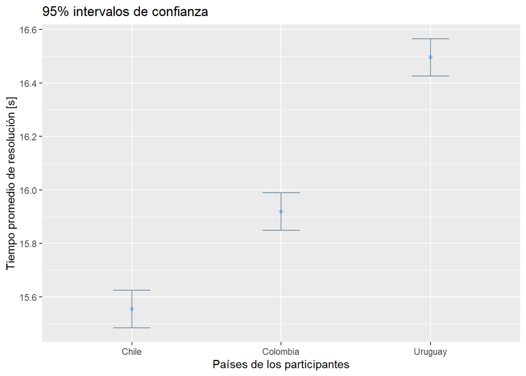

```r
# Cambio los colores del grafico
g1[["layers"]][[1]][["aes_params"]] <- list(colour = "steelblue1", alpha = 0.7)
g1[["layers"]][[2]][["aes_params"]] <- list(colour = "steelblue3", alpha = 0.7)
g1[["layers"]][[3]][["aes_params"]] <- list(colour = "steelblue4", alpha = 0.7)
g1 <- g1 + ggtitle("95% intervalos de confianza")

print(g1)
```

Como se puede observar en el gráfico, las medias no se solapan y existe una distancia significativa entre cada una de ellas. De aquí podemos concluir que los participantes chilenos fueron los que tuvieron una menor media en el tiempo de resolución en relación a los otros 2 países, mientras que los participantes uruguayos fueron los más lentos, tardando casi 1 segundo más que los chilenos.

Y aunque parezca no ser necesario utilizar otro método de análisis, se hará una prueba de Tukey por rigurosidad:

```r
tukey <- TukeyHSD(prueba_anova$aov, "pais", ordered = TRUE, conf.level = 0.95)
print(tukey)
```

```
##   Tukey multiple comparisons of means
##     95% family-wise confidence level
##     factor levels have been ordered
##
## Fit: aov(formula = formula(aov_formula), data = data)
##
## $pais
##                       diff       lwr       upr   p adj
## Colombia-Chile   0.3648537 0.1998718 0.5298356 2.1e-06
## Uruguay-Chile    0.9420699 0.7737365 1.1104032 0.0e+00
## Uruguay-Colombia 0.5772162 0.4078877 0.7465448 0.0e+00
```

Dado que los valores obtenidos en p adj son todos menores a 0.05, se puede concluir que los países poseen diferencias significativas entre sí. Además se condice con lo visto en el gráfico, teniendo la diferencia más grande entre Uruguay y Chile, de 0.942, y la diferencia más pequeña entre Colombia y Chile, de 0.365, mientras que la diferencia entre Uruguay y Colombia es de 0.577, pudiendo finalmente concluir que Chile, efectivamente, posee la media de tiempo de resolución de cubos rubik del tipo 3x3x3 más pequeña, seguido por Colombia, y quedando Uruguay con la media más alta.

2. Propongan una pregunta de investigación relacionada a los diferentes motores de bases de datos relacionales que necesite ser analizado por medio de un procedimiento ANOVA para muestras independientes con un factor que tenga entre 4 y 6 niveles. Luego invente una población para cada grupo con 5.000 datos, asegurando que cumpla las suposiciones de esta prueba.

Se plantea la siguiente pregunta de investigación:

¿Existen diferencias significativas en el tiempo promedio de ejecución de una consulta SQL compleja entre distintos motores de bases de datos relacionales?

Para abordar este problema, definimos las siguientes variables:

- Variable Independiente (Factor): Motor de base de datos relacional que es una variable categórica que cuenta con exactamente 4 niveles: MySQL, PostgreSQL, SQL Server, Oracle Database.
- Variable dependiente: Tiempo de ejecución de la consulta SQL. Es una variable numérica continua, medida en segundos, que representa cuánto tarda la máquina en finalizar el proceso desde inicio a fin.

Este escenario cumple con los requisitos para ser analizado mediante un ANOVA de una vía para muestras independientes por las siguientes razones:

```r
set.seed(123) # se agrega una semilla

n <- 5000
ds <- 6  # se fija una desviación estándar

#se agregan medias diferentes
mysql_tiempo      <- rnorm(n, mean = 52, sd = ds)
postgres_tiempo   <- rnorm(n, mean = 48, sd = ds)
sqlserver_tiempo  <- rnorm(n, mean = 55, sd = ds)
oracle_tiempo     <- rnorm(n, mean = 50, sd = ds)


motores <- c("MySQL", "PostgreSQL", "SQL Server", "Oracle")
tiempos <- c(mysql_tiempo, postgres_tiempo, sqlserver_tiempo, oracle_tiempo)

motor_factor <- factor(rep(motores, each = n))

datos_sql <- data.frame(
  Motor = motor_factor,
  Tiempo = tiempos
)

# vista de los datos
summary(datos_sql)
```

```
##         Motor          Tiempo
##  MySQL     :5000   Min.   :24.93
##  Oracle    :5000   1st Qu.:46.78
##  PostgreSQL:5000   Median :51.18
##  SQL Server:5000   Mean   :51.22
##                    3rd Qu.:55.64
##                    Max.   :73.61
```

Podemos decir que la población creada cumple con las condiciones para implementar ANOVA ya que:

- La variable dependiente es una variable numérica continua, medida en segundos, por lo que cumple con ser una escala de intervalos iguales.
- La población sigue una distribución normal ya que fue generada por la función “rnorm”, asegurando que los datos sigan una la distribución aproximadamente normal.
- La población tiene la misma varianza ya que se agregó como variable fija para usar “rnorm”.
- Las muestras cumplen con ser independientes y aleatorias dado que cada grupo es generado de forma separada por la función “rnorm” evitando la dependencia entre las 4 mediciones.